# Analyse du texte de la Horde du Contrevent de Alain Damasio

Victor Champonnois

3/24/2020

Ce document fait une analyse de texte de la Horde du Contrevent de Alain Damasio en se focalisant sur l’hétérogénéité dans les interventions des différents personnages. On essaye de voir si une analyse quantitative du texte nous permet de détecter des particularité du language des personnages.

Dans le texte, chaque intervention est précédée d'un symbole identifiant le personnage qui prend la parole. Comme ces symboles ne sont pas des caractères alphabétiques courant, on a pu les utiliser pour isoler chaque intervention et la relier au personnage. Ce document est créé par un notebook Rmarkdown, a partir du livre au format .txt (non inclus), et d'un script python produisant un tableau de fréquence des phonèmes à partir des données traitées dans la première partie du notebook. Ce tableau est ensuite réinjecté dans le notebook pour une présentation graphique.

## Nombre d’interventions

```
Caracole  Golgoth   Oroshi   Pietro      Sov
      50       33       70      128      177
```

Sov est le personnage qui fait le plus d’interventions. J’ai été surpris de constater que Pietro parle aussi beaucoup, alors que ses interventions ne m’ont pas particulièrement marquées dans le livre. Comme expliqué [ici](https://blogs.mediapart.fr/raphadasilva/blog/181117/la-horde-du-contrevent-un-aller-retour-eprouvant), même si le livre se veut polyphonique, il y a quand même des narrateurs principaux (Sov et Pietro notamment), qui parlent beaucoup plus que les autres et dont (on le verra), le language est plus neutre.

## Longueur moyene des interventions

[figure not shown]

Non seulement Sov fait le plus d’intervention, mais c’est aussi celui qui fait les interventions les plus longues. A l’inverse de Caracole qui est percutant mais concis.

## Longueur des phrases

[figure not shown]

La longueur des phrases est calculées en terme de caractère, pas de mots. Caracole et Pietro disent beaucoup de phrases très courtes, comme le montre la forme ramassée de la distribution. Sov, Aoi et Larco au contraire font au contraire des phrases plus longues.

## Longueur des mots

[figure not shown]

## Vocabulaire

Ici on calcul le nombre de mots différents utilisés divisé par le nombre total de mots utilisés. A la manière de cette célèbre analyse du vocabulaire chez les rappeurs :https://pudding.cool/projects/vocabulary/index.html

[figure not shown]

Sans surprise Caracole caracole en tête, presque 40% des mots qu’il utilise ne sont utilisés qu’une seule fois. Cela n’est guère étonnant pour ce personnage de vif, maître de l’art oratoire. Sov le plus bavard, se répète beaucoup plus. Mais plus l’on parle, plus il est difficile de ne pas répéter des mots, cela explique pourquoi ce graph ressemble au graph inverse du nombre d’interventions.

## Nuage de mots

Qu’est ce que les personnages disent ? On fait un nuage de mots pour voir les concepts qui sont les plus présents dans leurs interventions

J'ai du faire un peu de nettoyage des données, comme retirer la ponctuation et retirer les noms des personnages (je suis seulement intéressé par les mots, pas les noms.)

### Caracole

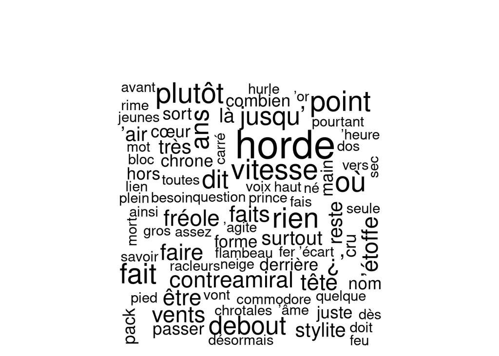

### Golgoth

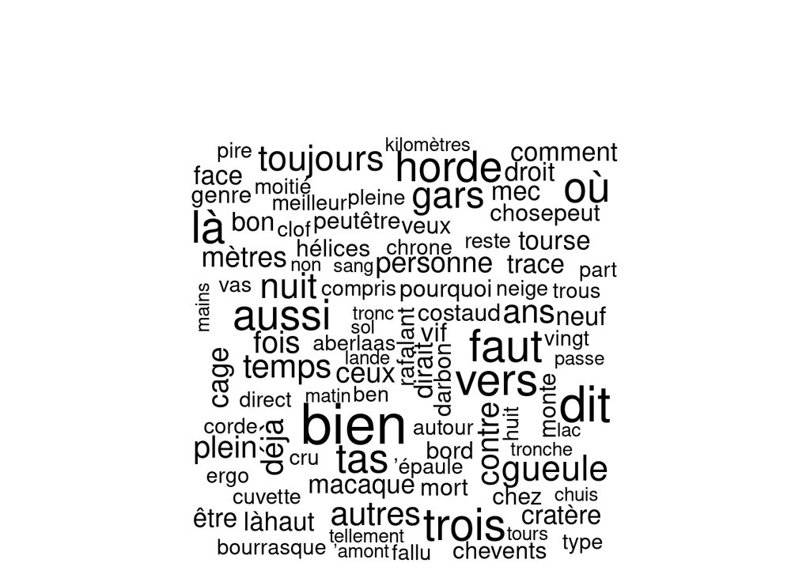

### Oroshi

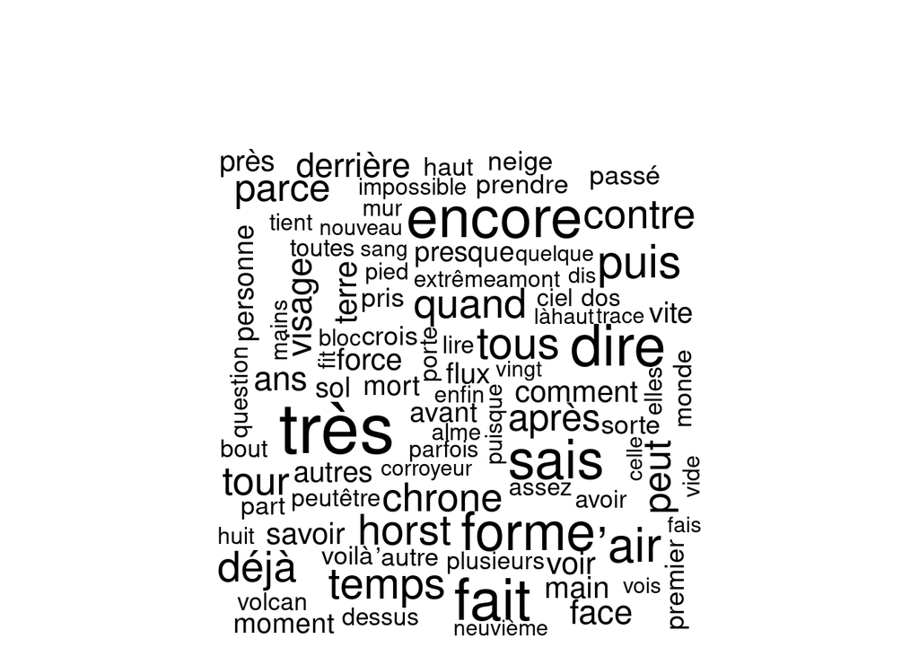

### Pietro

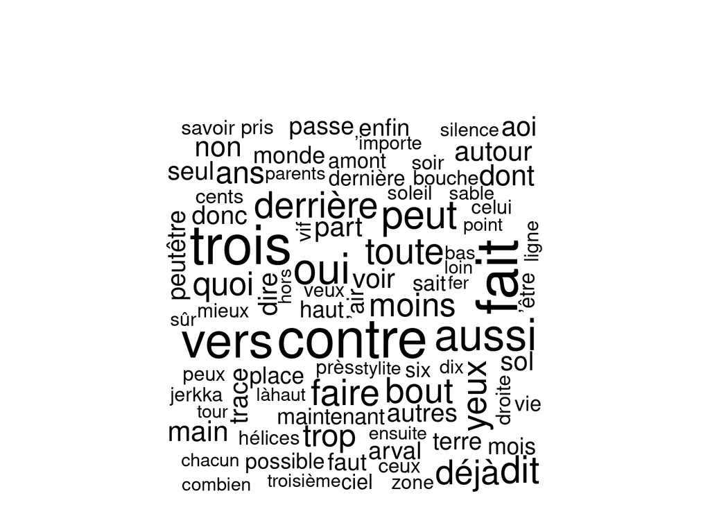

### Sov

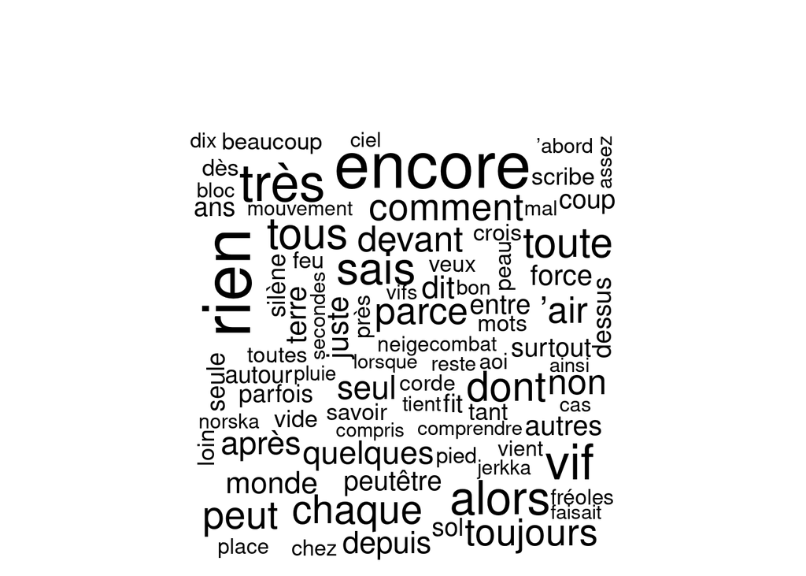

# Analyse des phonèmes

Alain Damasio a une approche particulière de l'écriture, très phonétique et orale. En effet, il raconte dans une interview :

> J’ai toujours travaillé sur une écriture assez physique, fondée sur les phonèmes, sur la puissance d’expressivité des consonnes, des voyelles.

[source](https://www.centrepompidou.fr/fr/magazine/article/alain-damasio-lecrivain-des-zones-imaginaires)

Dans cette partie, on va donc faire une analyse des phonèmes les plus utilisés par les personnages. On va essayer de voir de manière quantitative quel travaille il a fait sur le profil phonétique des personnages.

On utilise les phonèmes car c'est ce qui l'élement de texte qui se rapproche le plus d'une unité de son. Selon [wikipedia](https://fr.wikipedia.org/wiki/Phon%C3%A8me) :

> En phonologie, domaine de la linguistique, un phonème est la plus petite unité discrète [...] que l'on puisse isoler par segmentation dans la chaîne parlée.

Pour chaque personnage j’ai regardé quels phonèmes il utilisait le plus, en donnant sa “traduction” en français. Je me suis concentré sur Caracole, Golgoth et Sov car ils ont chacun une manière particulière de s’exprimmer surtout les deux premiers, Sov est plutôt pris comme référence.

### Sov

Sov a en effet une distribution presque plates des phonèmes, à l'inverse de Caracole et Golgoth il a une manière de parler presque "normale", qui fait qu'on n'observe pas d'utilisation d'un son en particulier plus que chez les autres personnages.

[figure not shown]

| Phonème | “Équivalent français” |
| --- | --- |
| ʃ | ch |
| f | f |
| i | i |
| d | d |
| n | n |

### Golgoth

Golgoth, à l'inverse a une distribution plus inégales, avec certains sons sur-utilisés. Par exemple :

> “Dès que **j**’ai reniflé le **b**l**aa**st, à l’odeur de froid, **j**’ai su que ç**a** allait **cha**rcler. **J**’ai enfoncé mon c**a**s**qu**e de **c**uir, plein front, san**g**lé le pourpoint, sec. **J**usqu’au **g**roin.”

[figure not shown]

| Phonème | “Équivalent français” |
| --- | --- |
| ɡ | gu |
| ʃ | ch |
| a | a |
| b | b |
| ʒ | j |

### Caracole

Caracole a la même forme de distribution mais pour des phonèmes différents :

> “Des cy**ch**r**o**nes, des psy**ch**r**o**nes, des **ch**r**o**tales à la l**ou**che, en vrac, par pa**q**uets de cin**q**, par de **d**ouze, gris métallisé, r**ou**ge garance ou bleu **cou**rge, pour t**ou**tes les c**ou**rses et les dég**oû**ts, ne **f**uyez pas n**ou**s **au**tres, pas enc**o**re !”

[figure not shown]

> | Phonème | “Équivalent français” |
> | --- | --- |
> | ɔ | o ouvert |
> | o | o fermé |
> | f | f |
> | k | k |
> | u | ou |

## Note methodologique sur analyse des phonèmes

J'ai utilisé la libraire phonemizer pour détecter les phonèmes dans le texte. Afin d'identifier le profil phonétique des personnages, je voulais savoir quels sont ils utilisaient le plus, en tenant comptes des sons utilisés globalement dans le livre.

Je m'explique. En français on aura tendance à utiliser naturellement certains sons plutôt que d'autres. Je voulais prendre en compte cette tendance afin de mettre en valeur les idiosyncracies particulière de chaque personnage. J'ai donc calculé le nombre de fois ou chaque sons était utilisé, pour chaque personnage, puis au total. J'ai divisé le compte de chaque personnage par le compte total. J'obtiens un score d'utilisation du son qui tiens en compte l'utilisation du son tout personnage confondu. Par exemple, si Golgoth utilise le son "a" 200 fois dans le livre, et que le son "a" est utilisé 1000 fois dans le livre, tout personnage confondu, le score d'utilisation du son "a" pour golgoth est 200/1000 = 0.2.

Un problème se présentait cependant : Phonemizer trouvait de temps en temps, mais très rarement, des sons qui ne sont pas français, comme "ɒ" qui se retrouve par exemple en anglais dans "caught". Afin d'éviter ce problème, j'ai retiré les phonèmes qui ne font pas partie de l'alphabet phonétique français. J'ai trouvé l'alphtabet phonétique français [ici](https://fr.wikipedia.org/wiki/Aide:Alphabet_phon%C3%A9tique_fran%C3%A7ais). J'ai retiré les semi voyelles et les sons "ŋ" (ng de parking) et "ɑ" (â de pâtes) car elles sont trop rares et forment des valeurs abbérantes.

## Annexe : code R

```
library(svglite)
knitr::opts_chunk$set(message = F,
    warning = F,
    echo = FALSE,
    dev = "svglite")

library(tidyverse)
library(tokenizers)
library(tm)
library(wordcloud)

theme_set(theme_minimal())

rm(list = ls())
# setwd("~/damasio/")
df = readChar("data/damasio.txt", nchars = file.info("data/damasio.txt")$size)

letters = strsplit(df,'')[[1]]
# \f = new page
# \n = new line

# remove new page
df = gsub("\f", "", df)
df_all = df

# characters
perso = c("Ω", "∂", "◊", "∆", "¬", "≈",  "∫",   "‹›",  "π", "¿", "‘,", "\\)-", "ˇ•", "8", "x", "(·)", "~", "√", "]]", "\\)")

# extract each character's paragraphs
perso_nl = sapply(perso, function(x) paste("\\n", x, sep = ""))


for (pers in perso_nl){
    split =  paste("(?<=.)(?=", pers, ")", sep = "")
    df = strsplit(x = df, split = split, perl = T)
    df = unlist(df)
}

# remove new line
df = gsub("\n", " ", df)
```

[output cut: 113 more lines]

```
    ggtitle("Concentration des phonèmes")

df_phonemes %>% filter(perso=="Caracole") %>%
    ggplot(., aes(x = reorder(phoneme, -weighted_count_by_phoneme), y= weighted_count_by_phoneme)) +
    geom_bar(stat = "identity", colour="black", fill="white") +
    ylab("Fréquence du phonème") +
    xlab("Phonèmes") +
    ggtitle("Concentration des phonèmes")

df_phonemes %>% filter(perso=="Sov") %>%
    ggplot(., aes(x = reorder(phoneme, -weighted_count_by_phoneme), y= weighted_count_by_phoneme)) +
    geom_bar(stat = "identity", colour="black", fill="white") +
    ylab("Fréquence du phonème") +
    xlab("Phonèmes") +
    ggtitle("Concentration des phonèmes")
```

## Annexe : code python

```
from nltk.corpus import cmudict
import pandas as pd
from collections import Counter
from phonemizer import phonemize # see https://github.com/bootphon/phonemizer
import json
import numpy as np


def filter_and_join(row):
    row = filter(None, row)
    return " ".join(row)

def phonemize_speech(speech):
    # speech is a string
    try:
        return phonemize(speech, language="fr-fr", backend="espeak", language_switch="remove-flags")
    except:
        pass

print("Read input file")

df= pd.read_csv("data/damasio_processed.csv", sep=",")
df = df.drop("Unnamed: 0", axis=1)

print("Convert text to phonemes")

df["phonemized"] = df.apply(lambda row: phonemize_speech(row.speech), axis=1)

print("Count phonemes for each perso")

df_aggregated = df.groupby(['perso'])['phonemized'].apply(filter_and_join).reset_index()
df_aggregated["count"] = df_aggregated.apply(lambda row: Counter(row.phonemized), axis=1)
df = pd.DataFrame([[i, k, v] for i, d in df_aggregated[['perso', 'count']].values for k, v in d.items()],
    columns=['perso', 'phoneme', 'count'])

print("Remove spaces")

df['phoneme'].replace(' ', np.nan, inplace=True)
df.dropna(subset=['phoneme'], inplace=True)

print("Remove non-french phonemes")

french_phonemes = pd.read_csv("data/french_phonemes.csv")
french_phonemes_list = [item[0].strip() for item in french_phonemes.values.tolist()]
df = df[df['phoneme'].isin(french_phonemes_list)]


print("Count weighted by phoneme sum")

sum_by_phoneme = df.groupby('phoneme')["count"].sum()
df["weighted_count_by_phoneme"] = df.apply(lambda row: row["count"]/sum_by_phoneme[row["phoneme"]], axis=1)


print("Count weighted by perso sum")

sum_by_perso = df.groupby('perso')["count"].sum()
df["weighted_count_by_perso"] = df.apply(lambda row: row["count"]/sum_by_perso[row["perso"]], axis=1)

print("Set perso as index and save")

df.to_csv("data/phonemes.csv", index=False)
```